# SWS_NWCA

Wills et al

January 4, 2018

comparing datasets

### Bring NWCA and RaCA datasets with SOC and bulk density from publicly availalbe data. Add location information which is sensitve and only shared with permission.

**RaCA** - Rapid Carbon Assessment Project. Information and data available at https://www.nrcs.usda.gov/wps/portal/nrcs/detail/soils/survey/?cid=nrcs142p2_054164

**NWCA** - National Wetland Condition Assessment. Information and data available at: https://www.nrcs.usda.gov/wps/portal/nrcs/detail/soils/survey/?cid=nrcs142p2_054164 Data for this project was made available as part of the soil property cooperation with Kellogg Soil Survey Laboratory.

**this code chunk downloads data into the folder with this project - uncomment to run**

```r
raca.url <- "https://nrcs.box.com/shared/static/nivz52qvsgyalx5zir8sgcu7lpp048pl.csv"
ifelse(!file.exists("RaCA_samples.csv"), download.file(raca.url,
    destfile = paste0("RaCA_samples.csv")), "File already downloaded")
```

```
# [1] "File already downloaded"
```

```r
nwca.url <- "https://nrcs.box.com/shared/static/u3qahrgycjzenwxykiabh93cnmk4r1e6.csv"
ifelse(!file.exists("nwca.SOCsamples_5-10.csv"), download.file(nwca.url,
    destfile = paste0("nwca.SOCsamples_5-10.csv")), "File already downloaded")
```

```
# [1] "File already downloaded"
```

## Read Data into R and Prep

#### Combine dataset into one

- Add location data
- Check field names
- Select relevant fields
- Harmonize datasets
- Rename to same field names
- Add SET to denote dataset
- Add any missing fields (assign values or unknown)
  - LU - to match RaCA W- wetland, C- cropland, P- pastureland, F - Forestland, X- CRP, U added for unknown

*Master Horizons (M) set for each dataset in previous data management* *Texture labels need to be assessed in ensure the same abbreviations are being used*

```r
raca <- read.csv(paste0("RaCA_samples.csv"))

raca.loc <- read.csv("RaCA_xy.csv")

raca <- left_join(raca, raca.loc, by = c(rcasiteid = "RaCA_site"))

raca$CALC_SOC <- ifelse(!is.na(raca$caco3), ifelse(raca$caco3 >
    0, raca$c_tot_ncs - (raca$caco3 * 0.12), raca$c_tot_ncs),
    raca$c_tot_ncs)
raca$SOC <- ifelse(raca$CALC_SOC < 0, 0, raca$CALC_SOC)
r <- raca[!is.na(raca$Measure_BD), c("samp", "upedon", "TOP",
    "BOT", "hzn_desgn", "Model_desg", "M", "texture", "fragvolc",
    "SOC", "Measure_BD", "Model_BD", "LU", "Lat", "Lon")]
names(r) <- c("samp_id", "Pedon_ID", "Top", "Bottom", "Hzn_name",
    "Model_desg", "M", "Texture", "CoarseFrag", "SOC", "BD",
    "RF.BD", "LU", "Lat", "Lon")
r$SET <- "RaCA"
r$Clay <- NA



nwca <- read.csv("nwca.SOCsamples_5-10.csv")
nwca.loc <- read.csv("NWCA2011_SITEINFO_081315.csv")

nwca <- left_join(nwca, nwca.loc, by = "UID")

w <- nwca[!is.na(nwca$BD), c("samp", "Pedon", "top", "bottom",
    "HORIZON", "Model_desg", "M", "TEXTURE_CLASS", "CLAY", "ROCK_FRAGMENTS",
    "SOC", "BD", "Model", "AA_CENTER_LAT", "AA_CENTER_LON")]


names(w) <- c("samp_id", "Pedon_ID", "Top", "Bottom", "Hzn_name",
    "Model_desg", "M", "Texture", "Clay", "CoarseFrag", "SOC",
    "BD", "RF.BD", "Lat", "Lon")
w$LU <- "W"
w$SET <- "NWCA"
w$Pedon_ID <- as.factor(w$Pedon_ID)

# combine dataset into one - missing values are filled with
# NA
combo <- rbind(r, w)

# there are a number of really high bulk density numbers -
# primarily in the ISCN set - need to investigate further
combo <- combo %>% filter(BD < 2)

# knitr::kable(n_M),digits = 1, col.names =names(n_S),
# caption = 'Number of Samples in each Dataset', row.names
# =F, padding= 2)
```

## Compare Datasets

Use dplyr (with piping) to format and ggplot to create graphs

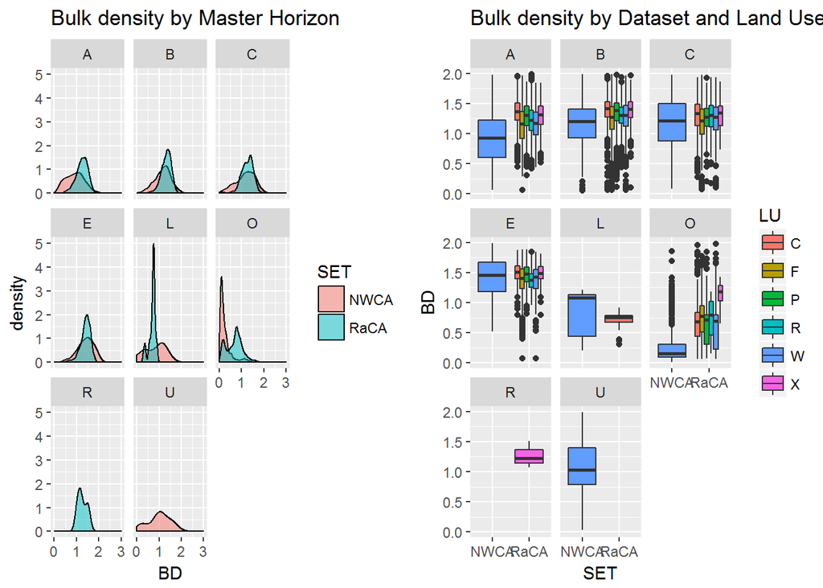

```r
d <- combo %>% ggplot(aes(BD)) + geom_density(aes(fill = SET),
    alpha = 0.5) + scale_x_continuous(limits = c(0, 3)) + facet_wrap(~M) +
    ggtitle("Bulk density by Master Horizon")


b <- combo %>% # filter(!is.na(BD)) %>%
ggplot(aes(y = BD, x = SET)) + geom_boxplot(aes(fill = LU)) +
    facet_wrap(~M) + ggtitle("Bulk density by Dataset and Land Use/Cover Class")


grid.arrange(d, b, ncol = 2)
```

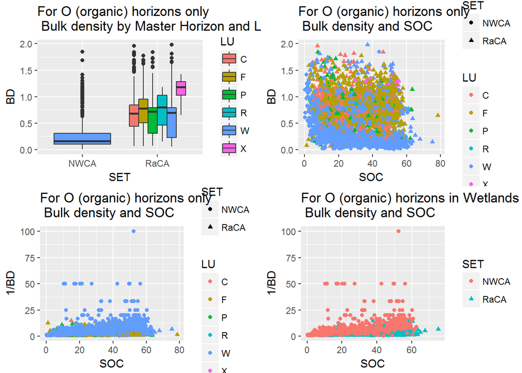

```r
o <- combo %>% filter(!is.na(BD) & M == "O") %>% ggplot(aes(y = BD,
    x = SET)) + geom_boxplot(aes(fill = LU)) + ggtitle("For O (organic) horizons only \n Bulk density by Master Horizon and Land Use/Cover Class")


s <- combo %>% filter(!is.na(BD) & M == "O") %>% ggplot(aes(y = BD,
    x = SOC)) + geom_point(aes(color = LU, shape = SET)) + ggtitle("For O (organic) horizons only \n Bulk density and SOC")


S <- combo %>% filter(!is.na(BD) & M == "O") %>% ggplot(aes(y = 1/BD,
    x = SOC)) + geom_point(aes(color = LU, shape = SET)) + ggtitle("For O (organic) horizons only \n Bulk density and SOC")

Sw <- combo %>% filter(!is.na(BD) & M == "O" & LU == "W") %>%
    ggplot(aes(y = 1/BD, x = SOC)) + geom_point(aes(color = SET,
    shape = SET)) + ggtitle("For O (organic) horizons in Wetlands only \n Bulk density and SOC")

grid.arrange(o, s, S, Sw, ncol = 2)
```

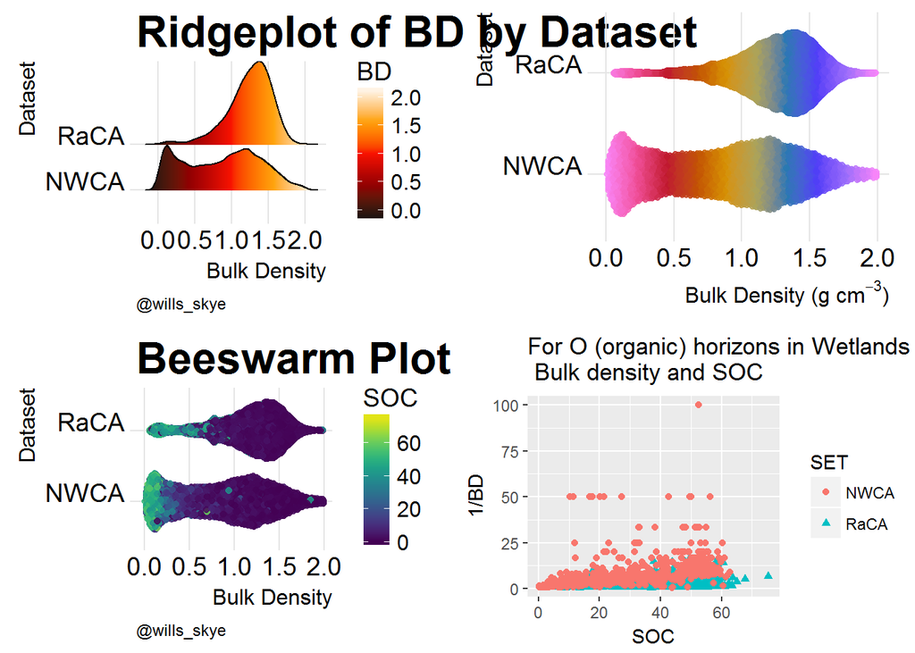

```r
# joy plot with continuous fill
R <- combo %>% filter(!is.na(BD)) %>% ggplot(aes(x = BD, y = SET,
    fill = ..x..)) + geom_joy_gradient() + scale_fill_gradientn(colours = cet_pal(5,
    name = "fire"), name = "BD") + theme_joy() + theme(plot.caption = element_text(hjust = 0,
    size = 9), axis.title = element_text(size = 12), plot.title = element_text(size = 24)) +
    labs(x = "Bulk Density", y = "Dataset", caption = "@wills_skye",
        title = "Ridgeplot of BD by Dataset")




# bee swarm
B <- combo %>% filter(!is.na(BD)) %>% ggplot(aes(x = BD, y = SET,
    color = BD)) + geom_quasirandom(alpha = 0.82, groupOnX = FALSE) +
    scale_color_gradientn(colours = cet_pal(10, name = "cyclic_mrybm_35-75_c68_n256"),
        name = "BD") + theme_joy() + theme(plot.caption = element_text(hjust = 0,
    size = 9), axis.title = element_text(size = 12), plot.title = element_text(size = 24)) +
    labs(x = "Bulk Density", y = "Dataset", caption = "@wills_skye",
        title = "Beeswarm Plot of BD by Dataset")



# add SOC measurement for visulaization
B_C <- combo %>% filter(!is.na(BD) & !is.na(SOC)) %>% ggplot(aes(x = BD,
    y = SET, color = SOC)) + geom_quasirandom(alpha = 0.82, groupOnX = FALSE) +
    scale_color_viridis() + theme_joy() + theme(plot.caption = element_text(hjust = 0,
    size = 9), axis.title = element_text(size = 12), plot.title = element_text(size = 24)) +
    labs(x = "Bulk Density", y = "Dataset", caption = "@wills_skye",
        title = "Beeswarm Plot of BD by Dataset")



# limit to organic horizons bee swarm
Bo <- combo %>% filter(!is.na(BD) & M == "O") %>% ggplot(aes(x = BD,
    y = SET, color = BD)) + geom_quasirandom(alpha = 0.82, groupOnX = FALSE) +
    scale_color_gradientn(colours = cet_pal(10, name = "cyclic_mrybm_35-75_c68_n256"),
        name = "BD") + theme_joy() + theme(plot.caption = element_text(hjust = 0,
    size = 9), axis.title = element_text(size = 12), plot.title = element_text(size = 24)) +
    labs(x = "Bulk Density", y = "Dataset", caption = "@wills_skye",
        title = "Bulk Density of Organic Horizons \n by Dataset")



Bow <- combo %>% filter(!is.na(BD) & M == "O" & LU == "W") %>%
    ggplot(aes(x = BD, y = SET, color = BD)) + geom_quasirandom(alpha = 0.82,
    groupOnX = FALSE) + scale_color_gradientn(colours = cet_pal(10,
    name = "cyclic_mrybm_35-75_c68_n256"), name = "BD") + theme_joy() +
    theme(plot.caption = element_text(hjust = 0, size = 9), axis.title = element_text(size = 12),
        plot.title = element_text(size = 24)) + labs(x = "Bulk Density",
    y = "Dataset", caption = "@wills_skye", title = "Bulk Density of O Horizons \n in Wetlands by Dataset")



# with SOC measurement
BoC <- combo %>% filter(!is.na(BD) & !is.na(SOC) & M == "O") %>%
    ggplot(aes(x = BD, y = SET, color = SOC)) + geom_quasirandom(alpha = 0.82,
    groupOnX = FALSE) + scale_color_viridis(option = "viridis") +
    theme_joy() + theme(plot.caption = element_text(hjust = 0,
    size = 9), axis.title = element_text(size = 12), plot.title = element_text(size = 24)) +
    labs(x = "Bulk Density", y = "Dataset", caption = "@wills_skye",
        title = "Bulk Density of O Horizons \n by Dataset")



BowC <- combo %>% filter(!is.na(BD) & !is.na(SOC) & M == "O" &
    LU == "W") %>% ggplot(aes(x = BD, y = SET, color = SOC)) +
    geom_quasirandom(alpha = 0.82, groupOnX = FALSE) + scale_color_viridis(option = "viridis") +
    theme_joy() + theme(plot.caption = element_text(hjust = 0,
    size = 9), axis.title = element_text(size = 12), plot.title = element_text(size = 24)) +
    labs(x = "Bulk Density", y = "Dataset", caption = "@wills_skye",
        title = "Bulk Density of O Horizons \n in Wetlands by Dataset")



BowCc <- combo %>% filter(!is.na(BD) & !is.na(SOC) & M == "O" &
    LU == "W" & SOC > 20) %>% ggplot(aes(x = BD, y = SET, color = SOC)) +
    geom_quasirandom(alpha = 0.82, groupOnX = FALSE) + scale_color_viridis(option = "viridis") +
    theme_joy() + theme(plot.caption = element_text(hjust = 0,
    size = 9), axis.title = element_text(size = 12), plot.title = element_text(size = 14)) +
    labs(x = "Bulk Density", y = "Dataset", caption = "@wills_skye",
        title = "Bulk Density of O Horizons with SOC > 20% \n in Wetlands by Dataset")



BowT <- combo %>% filter(!is.na(BD) & !is.na(SOC) & M == "O" &
    LU == "W") %>% ggplot(aes(x = BD, y = SET, color = Top)) +
    geom_quasirandom(alpha = 0.5, groupOnX = FALSE) + scale_color_viridis(option = "magma") +
    theme_joy() + theme(plot.caption = element_text(hjust = 0,
    size = 9), axis.title = element_text(size = 12), plot.title = element_text(size = 24)) +
    labs(x = "Bulk Density", y = "Dataset", caption = "@wills_skye",
        title = "Bulk Density of O Horizons \n in Wetlands by Dataset")



BowTc <- combo %>% filter(!is.na(BD) & !is.na(SOC) & M == "O" &
    LU == "W" & SOC > 20) %>% ggplot(aes(x = BD, y = SET, color = Top)) +
    geom_quasirandom(alpha = 0.5, groupOnX = FALSE) + scale_color_viridis(option = "magma") +
    theme_joy() + theme(plot.caption = element_text(hjust = 0,
    size = 9), axis.title = element_text(size = 12), plot.title = element_text(size = 24)) +
    labs(x = "Bulk Density", y = "Dataset", caption = "@wills_skye",
        title = "Bulk Density of O Horizons \n in Wetlands by Dataset")



# prep select graphs for export
B <- combo %>% filter(!is.na(BD)) %>% ggplot(aes(x = BD, y = SET,
    color = BD)) + geom_quasirandom(alpha = 0.82, groupOnX = FALSE) +
    scale_color_gradientn(colours = cet_pal(10, name = "cyclic_mrybm_35-75_c68_n256"),
        guide = FALSE) + theme_joy() + theme(plot.caption = element_text(hjust = 0,
    size = 9), axis.title = element_text(size = 12), plot.title = element_text(size = 24)) +
    # labs(x='Bulk Density',y='Dataset',caption='@wills_skye',
# title='Beeswarm Plot of BD by Dataset')
labs(x = expression(paste("Bulk Density (g cm"^-3, ")")), y = "Dataset")



# ggsave('BDswarm_all.png', plot = B, device = 'png', path =
# 'C:/Users/skye.wills/ownCloud/AGU_BD-OMgraphs/poster',
# scale = 1, width = 6, height = 3, units = 'in', dpi = 600,
# limitsize = TRUE)


BowC <- combo %>% filter(!is.na(BD) & !is.na(SOC) & M == "O" &
    LU == "W") %>% ggplot(aes(x = BD, y = SET, color = SOC)) +
    geom_quasirandom(alpha = 0.82, groupOnX = FALSE) + scale_color_viridis(option = "viridis") +
    theme_joy() + theme(plot.caption = element_text(hjust = 0,
    size = 9), axis.title = element_text(size = 12), plot.title = element_text(size = 24)) +
    # labs(x='Bulk Density',y='Dataset',caption='@wills_skye',
# title='Bulk Density of O Horizons \n in Wetlands by
# Dataset')
labs(x = expression(paste("Bulk Density (g cm"^-3, ")")), y = "Dataset",
    color = "SOC (%)")



grid.arrange(R, B, B_C, Sw, ncol = 2)
```

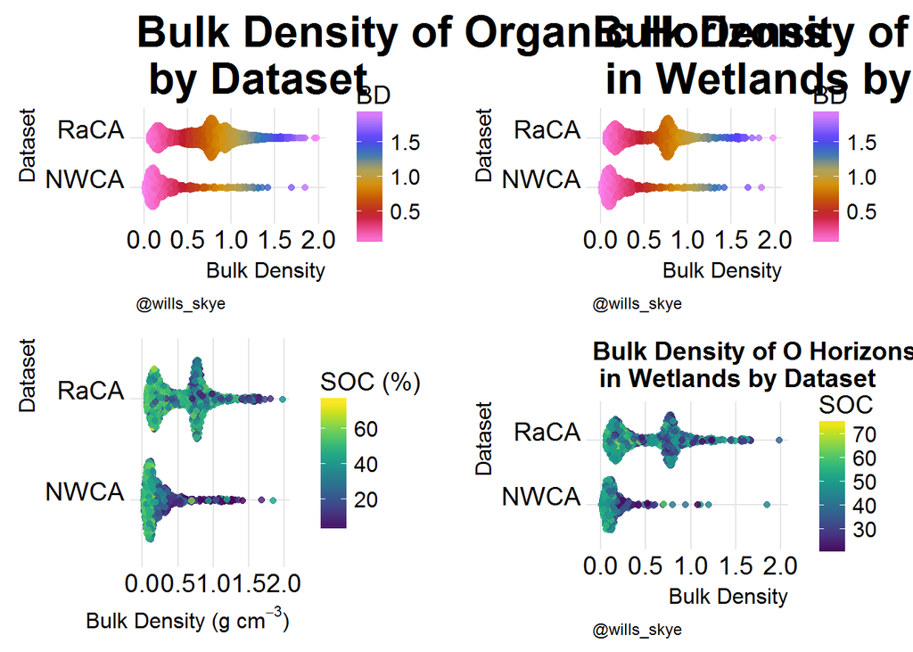

```r
grid.arrange(Bo, Bow, BowC, BowCc, ncol = 2)
```

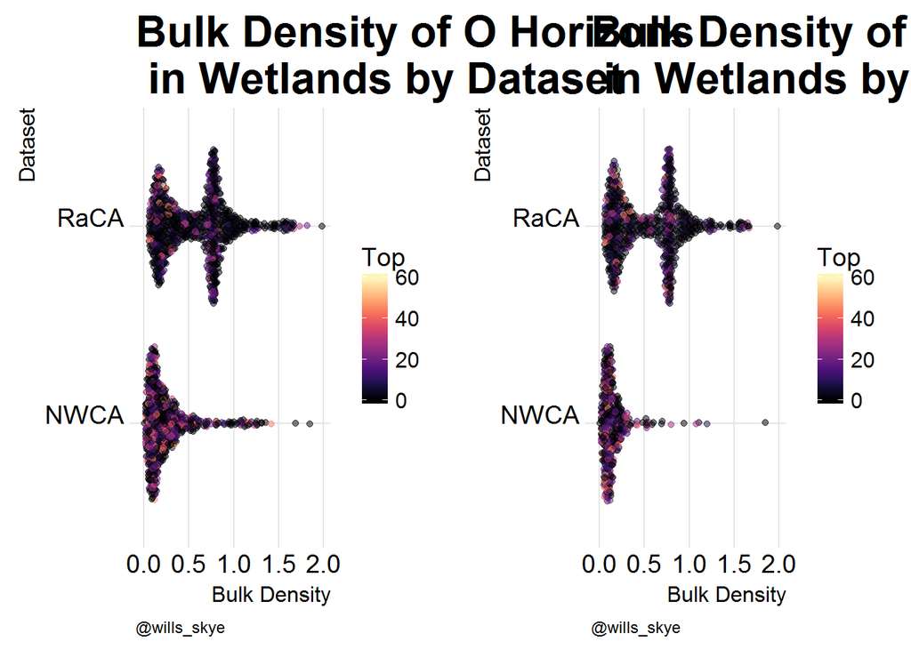

```r
grid.arrange(BowT, BowTc, ncol = 2)
```

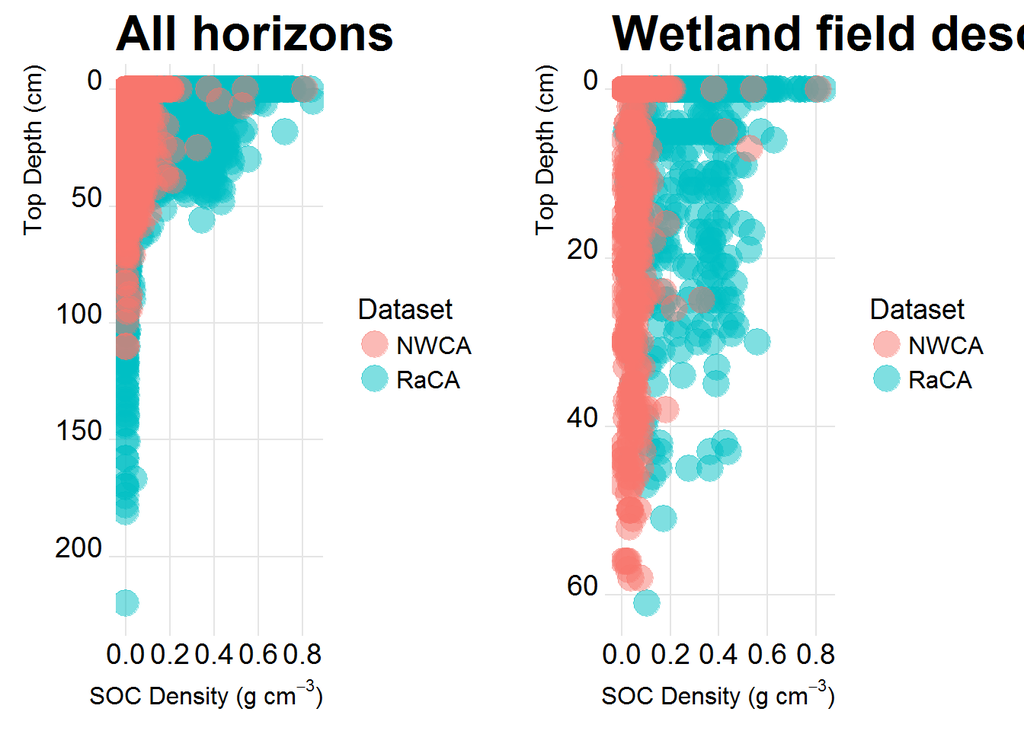

```r
Den1 <- combo %>% mutate(SOCden = BD * SOC/100) %>% filter(!is.na(BD) &
    !is.na(SOC)) %>%
ggplot(aes(x = SOCden, y = Top, color = SET)) + geom_point(size = 6,
    alpha = 0.5) + theme_joy() + scale_y_reverse() + theme(plot.caption = element_text(hjust = 0,
    size = 9), axis.title = element_text(size = 12), plot.title = element_text(size = 24)) +
    # labs(x='Bulk Density',y='Dataset',caption='@wills_skye',
# title='Bulk Density of O Horizons \n in Wetlands by
# Dataset')
labs(x = expression(paste("SOC Density (g cm"^-3, ")")), y = "Top Depth (cm)",
    color = "Dataset", title = "All horizons")


Den <- combo %>% mutate(SOCden = BD * SOC/100) %>% filter(!is.na(BD) &
    !is.na(SOC) & M == "O" & LU == "W") %>%
ggplot(aes(x = SOCden, y = Top, color = SET)) + geom_point(size = 6,
    alpha = 0.5) + theme_joy() + scale_y_reverse() + theme(plot.caption = element_text(hjust = 0,
    size = 9), axis.title = element_text(size = 12), plot.title = element_text(size = 24)) +
    # labs(x='Bulk Density',y='Dataset',caption='@wills_skye',
# title='Bulk Density of O Horizons \n in Wetlands by
# Dataset')
labs(x = expression(paste("SOC Density (g cm"^-3, ")")), y = "Top Depth (cm)",
    color = "Dataset", title = "Wetland field described O horizons")




#

Den2 <- combo %>% filter(!is.na(BD) & !is.na(SOC)) %>% mutate(SOCden = BD *
    SOC/100) %>% mutate(D = cut(Top, breaks = c(0, 10, 25, 50,
    100), labels = c("0 - 10cm", "10 - 25cm", "25 - 50cm", "50 - 100cm"))) %>%
    mutate(D = factor(D, levels = rev(levels(D)))) %>% filter(!is.na(D)) %>%
    group_by(samp_id, M, LU, SET, D) %>% summarize(SD = mean(SOCden,
    na.rm = T)) %>% ggplot(sata = DD2, aes(y = SD, x = D)) +
    geom_jitter(aes(color = M), size = 4, alpha = 0.5) + geom_boxplot(color = "grey",
    alpha = 0.5) + theme_joy() + scale_y_continuous(limits = c(0,
    0.5)) + coord_flip() + theme(plot.caption = element_text(hjust = 0,
    size = 9), axis.title = element_text(size = 12), plot.title = element_text(size = 24)) +
    # labs(x='Bulk Density',y='Dataset',caption='@wills_skye',
# title = ' Carbon Density of all horizons)
labs(x = expression(paste("SOC Density (g cm"^-3, ")")), y = "Depth Class (cm)",
    color = "Master Horizon", title = "All horizons") + facet_wrap(~SET)



Den2O <- combo %>% filter(!is.na(BD) & !is.na(SOC) & M == "O") %>%
    mutate(SOCden = BD * SOC/100) %>% mutate(D = cut(Top, breaks = c(0,
    10, 25, 50, 100), labels = c("0 - 10cm", "10 - 25cm", "25 - 50cm",
    "50 - 100cm"))) %>% mutate(D = factor(D, levels = rev(levels(D)))) %>%
    filter(!is.na(D)) %>% group_by(samp_id, M, LU, SET, D) %>%
    summarize(SD = mean(SOCden, na.rm = T)) %>% ggplot(sata = DD2,
    aes(y = SD, x = D)) + geom_jitter(color = "lightblue", size = 4,
    alpha = 0.75) + geom_boxplot(color = "grey", alpha = 0.75) +
    theme_joy() + scale_y_continuous(limits = c(0, 0.5)) + coord_flip() +
    theme(plot.caption = element_text(hjust = 0, size = 9), axis.title = element_text(size = 12),
        plot.title = element_text(size = 24)) + # labs(x='Bulk Density',y='Dataset',caption='@wills_skye',
# title = ' Carbon Density of all horizons)
labs(y = expression(paste("SOC Density (g cm"^-3, ")")), x = "Depth Class (cm)",
    color = "Master Horizon", title = "Organic horizons (field Described)") +
    facet_wrap(~SET)



Den2Oc <- combo %>% filter(!is.na(BD) & !is.na(SOC) & M == "O") %>%
    mutate(SOCden = BD * SOC/100) %>% mutate(D = cut(Top, breaks = c(0,
    10, 25, 50, 100), labels = c("0 - 10cm", "10 - 25cm", "25 - 50cm",
    "50 - 100cm"))) %>% mutate(D = factor(D, levels = rev(levels(D)))) %>%
    filter(!is.na(D)) %>% group_by(samp_id, M, LU, SET, D) %>%
    summarize(SD = mean(SOCden, na.rm = T), SOCm = mean(SOC)) %>%
    ggplot(sata = DD2, aes(y = SD, x = D)) + geom_jitter(aes(color = SOCm),
    size = 4, alpha = 0.95) + geom_boxplot(color = "grey", alpha = 0.75) +
    theme_joy() + scale_color_gradient2(low = "dark blue", mid = "white",
    high = "green", midpoint = 20) + scale_y_continuous(limits = c(0,
    0.5)) + coord_flip() + theme(plot.caption = element_text(hjust = 0,
    size = 9), axis.title = element_text(size = 12), plot.title = element_text(size = 24)) +
    # labs(x='Bulk Density',y='Dataset',caption='@wills_skye',
# title = ' Carbon Density of all horizons)
labs(y = expression(paste("SOC Density (g cm"^-3, ")")), x = "Depth Class (cm)",
    color = "% SOC", title = "SOCden with SOC \n Organic horizons, field described") +
    facet_wrap(~SET)



Den2Od <- combo %>% filter(!is.na(BD) & !is.na(SOC) & M == "O") %>%
    mutate(SOCden = BD * SOC/100) %>% mutate(D = cut(Top, breaks = c(0,
    10, 25, 50, 100), labels = c("0 - 10cm", "10 - 25cm", "25 - 50cm",
    "50 - 100cm"))) %>% mutate(D = factor(D, levels = rev(levels(D)))) %>%
    filter(!is.na(D)) %>% group_by(samp_id, M, LU, SET, D) %>%
    summarize(SD = mean(SOCden, na.rm = T), SOCm = mean(SOC),
        BDm = mean(BD)) %>% ggplot(sata = DD2, aes(y = SD, x = D)) +
    geom_jitter(aes(color = BDm), size = 4, alpha = 0.95) + geom_boxplot(color = "grey",
    alpha = 0.75) + theme_joy() + scale_color_gradient2(low = "black",
    mid = "white", high = "red", midpoint = 0.5) + scale_y_continuous(limits = c(0,
    0.5)) + coord_flip() + theme(plot.caption = element_text(hjust = 0,
    size = 9), axis.title = element_text(size = 12), plot.title = element_text(size = 24)) +
    # labs(x='Bulk Density',y='Dataset',caption='@wills_skye',
# title = ' Carbon Density of all horizons)
labs(y = expression(paste("SOC Density (g cm"^-3, ")")), x = "Depth Class (cm)",
    color = "Bulk Density \n g/cm3", title = "SOCden with BD \n Organic horizons, field described") +
    facet_wrap(~SET)



Den2OdW <- combo %>% filter(!is.na(BD) & !is.na(SOC) & M == "O" &
    LU == "W") %>% mutate(SOCden = BD * SOC/100) %>% mutate(D = cut(Top,
    breaks = c(0, 10, 25, 50, 100), labels = c("0 - 10cm", "10 - 25cm",
        "25 - 50cm", "50 - 100cm"))) %>% mutate(D = factor(D,
    levels = rev(levels(D)))) %>% filter(!is.na(D)) %>% group_by(samp_id,
    M, LU, SET, D) %>% summarize(SD = mean(SOCden, na.rm = T),
    SOCm = mean(SOC), BDm = mean(BD)) %>% ggplot(sata = DD2,
    aes(y = SD, x = D)) + geom_jitter(aes(color = BDm), size = 4,
    alpha = 0.95) + geom_boxplot(color = "grey", alpha = 0.75) +
    theme_joy() + scale_color_gradient2(low = "black", mid = "white",
    high = "red", midpoint = 0.5) + scale_y_continuous(limits = c(0,
    0.5)) + coord_flip() + theme(plot.caption = element_text(hjust = 0,
    size = 9), axis.title = element_text(size = 12), plot.title = element_text(size = 24)) +
    # labs(x='Bulk Density',y='Dataset',caption='@wills_skye',
# title = ' Carbon Density of all horizons)
labs(y = expression(paste("SOC Density (g cm"^-3, ")")), x = "Depth Class (cm)",
    color = "Bulk Density \n g/cm3", title = "Organic horizons, field described, \n in Wetlands") +
    facet_wrap(~SET)



# find samples that are high in OM, but also have high bulk
# density
sample_flag <- combo %>% filter(!is.na(BD) & !is.na(SOC) & M ==
    "O" & LU == "W") %>% mutate(SOCden = BD * SOC/100) %>% filter(SOC >
    10, BD > 0.5)


# find unique pedon id
Ped_flag <- sample_flag %>% group_by(Pedon_ID) %>% summarize(SOCdenM = mean(SOCden,
    na.rm = T), SOCm = mean(SOC), BDm = mean(BD), SDmax = max(SOCden),
    SOCmax = max(SOC), BDmax = max(BD))

raca_flag <- Ped_flag %>% right_join(raca %>% filter(!is.na(SOC)) %>%
    mutate(Pedon_ID = upedonid)) %>% filter(!is.na(SDmax))

raca_pedon_flag <- raca_flag %>% select(rcasiteid) %>% group_by(rcasiteid) %>%
    summarise()


grid.arrange(Den1, Den, ncol = 2)
```

[figure not shown]

```r
grid.arrange(Den2, Den2O, ncol = 2)
```

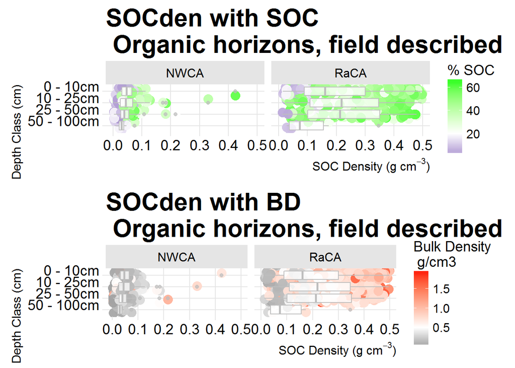

```r
grid.arrange(Den2Oc, Den2Od)
```

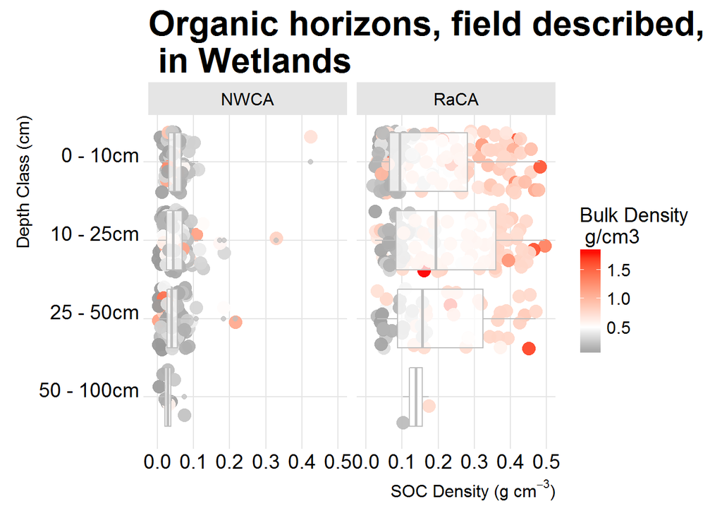

```r
Den2OdW
```

## Locations

Summarize by pedons, select all wetlands and plot locations How do we co-locate?

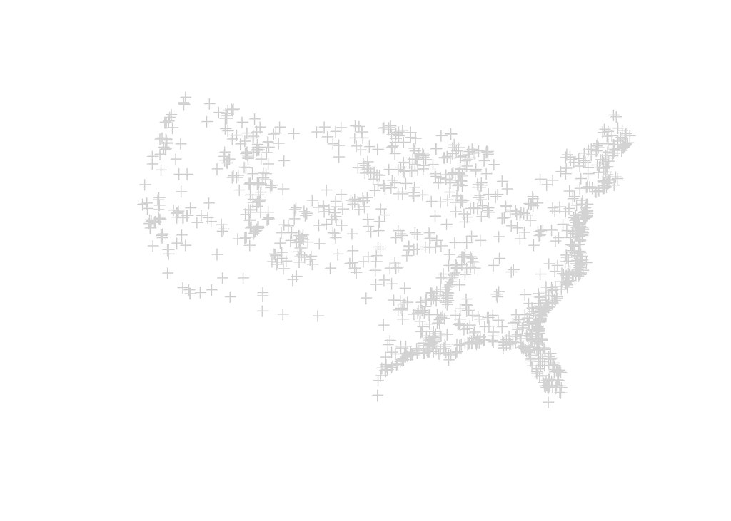

```r
library(png)
library(grid)

# one location per observation/pedon and clean lat/lon
C <- combo %>% filter(LU == "W" & Lat != 0) %>% select(SET, Pedon_ID,
    Lat, Lon, BD) %>% group_by(Pedon_ID) %>% mutate(Lat = ifelse(Lat ==
    0, NA, Lat), Lon = ifelse(Lon == 0, NA, Lon)) %>% summarize_all("min")

C_sp <- C

# create spatial object
names(C_sp) <- tolower(names(C_sp))
C_sp <- C_sp[complete.cases(C_sp), ]

# xy cooridanates
coordinates(C_sp) <- ~lon + lat
proj4string(C_sp) <- CRS("+proj=longlat +datum=WGS84")
C_sp <- spTransform(C_sp, CRS("+init=epsg:5070"))



us <- map("state", plot = FALSE)
us_sp <- {
    . <- map2SpatialLines(us, proj4string = CRS("+init=epsg:4326"))
    spTransform(., CRS("+init=epsg:5070"))
}


# plot all
plot(C_sp, col = "lightgrey")  # plot all points
```

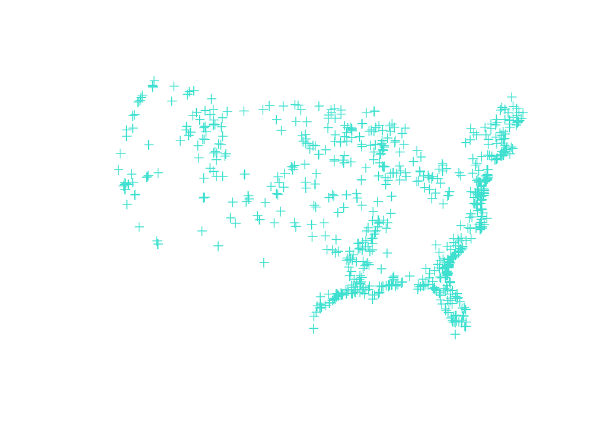

```r
# change color of NWCA points
setN <- C_sp$set == "NWCA"
plot(C_sp[setN, ], col = "turquoise")  # add selected zones to map
```

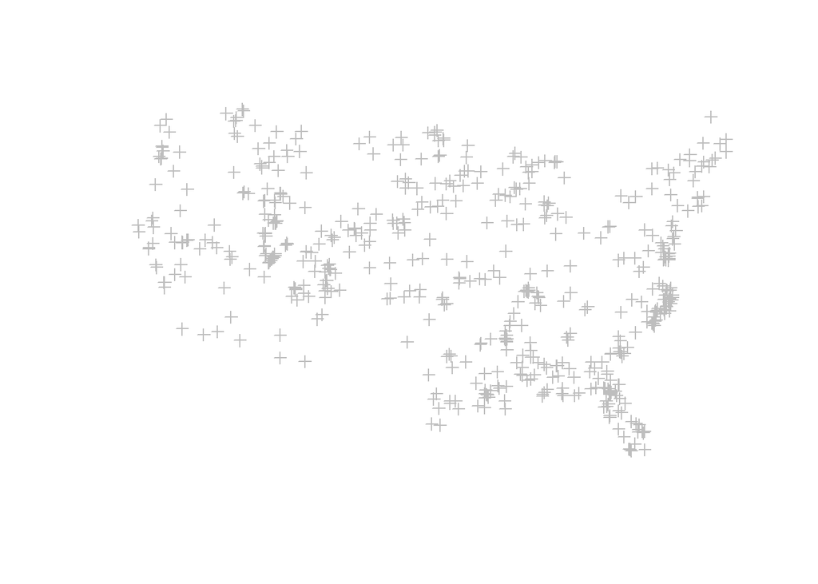

```r
# chang color of RACA points (wetlands)
plot(C_sp[C_sp$set == "RaCA", ], col = "grey")
```

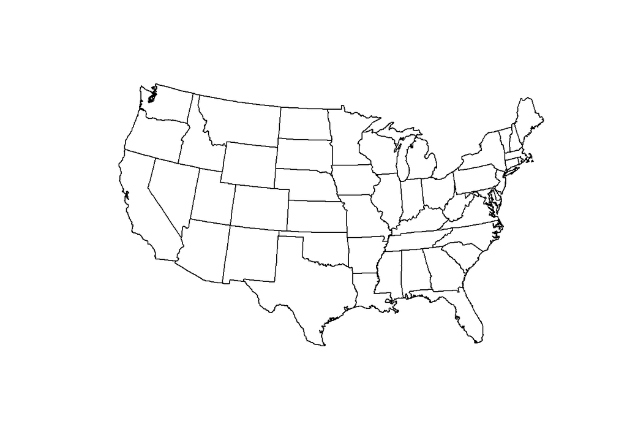

```r
plot(us_sp)
```

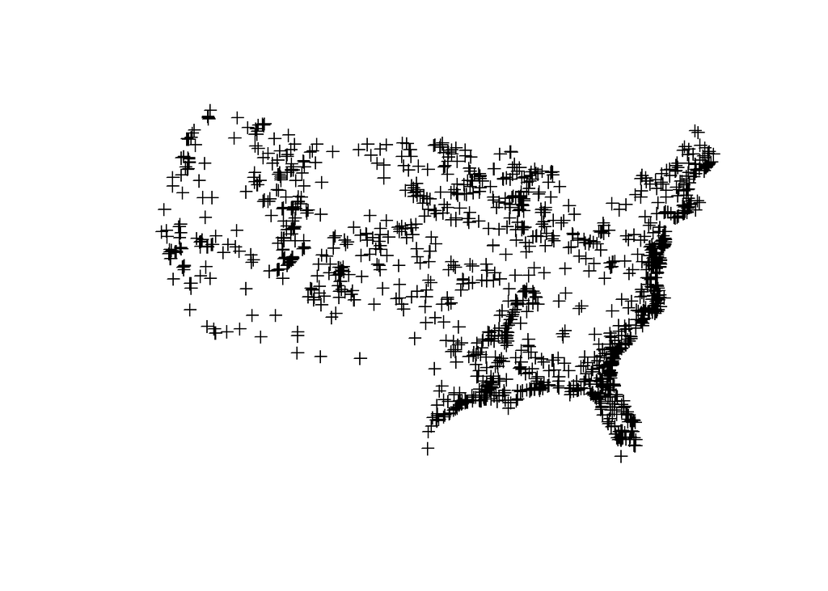

```r
# ======= spplot.points(C_sp)

####

cols <- brewer.pal(2, "RdYlBu")

C_sp$SET <- as.factor(C_sp$set)

plot(C_sp)
```

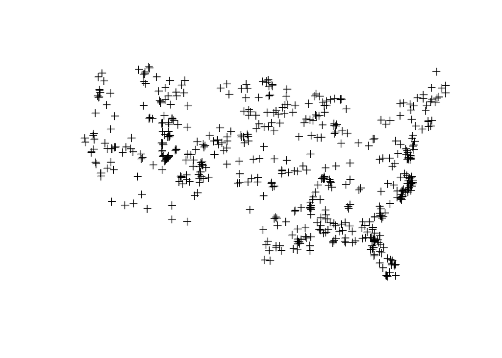

```r
plot(C_sp[C_sp$SET == "RaCA", ])
```

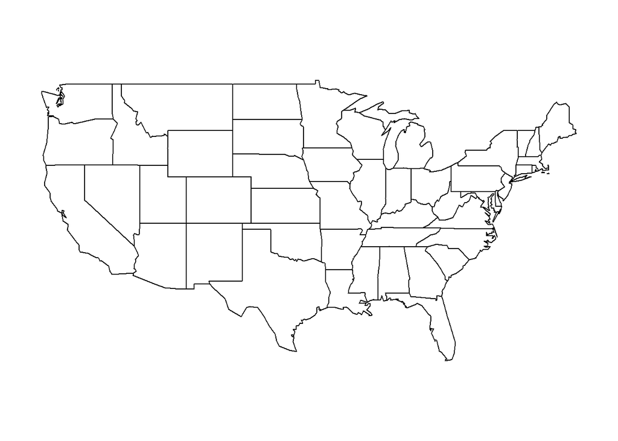

```r
par(mar = c(0, 0, 0, 0))

map("state")
```

```r
# points(C.sp, cex=0.5, pch=3, col='red'))


# mapview(C.sp)
```

use sf to create spatial stuff

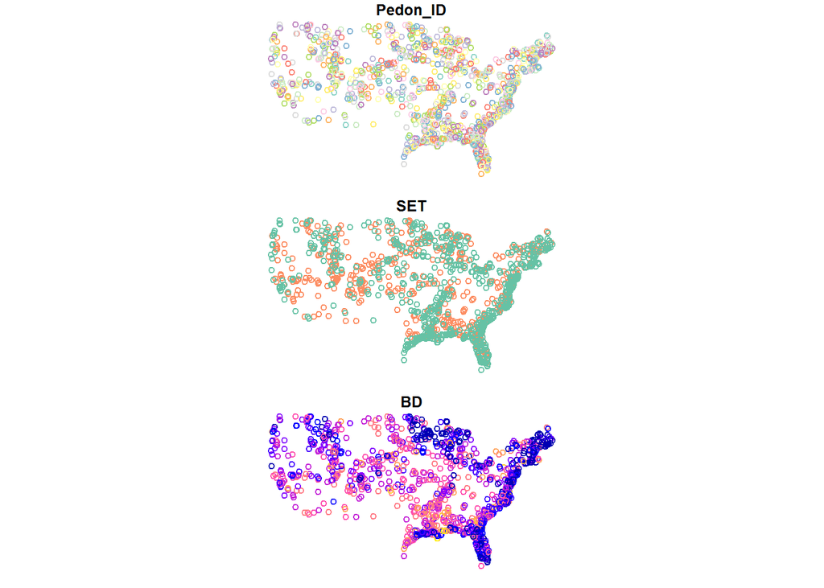

```r
library(sf)
# devtools::install_github('tidyverse/ggplot2')
# require(ggplot2)

Csf <- st_as_sf(C, coords = c("Lon", "Lat"), crs = "+proj=longlat +datum=WGS84")

plot(Csf)
```

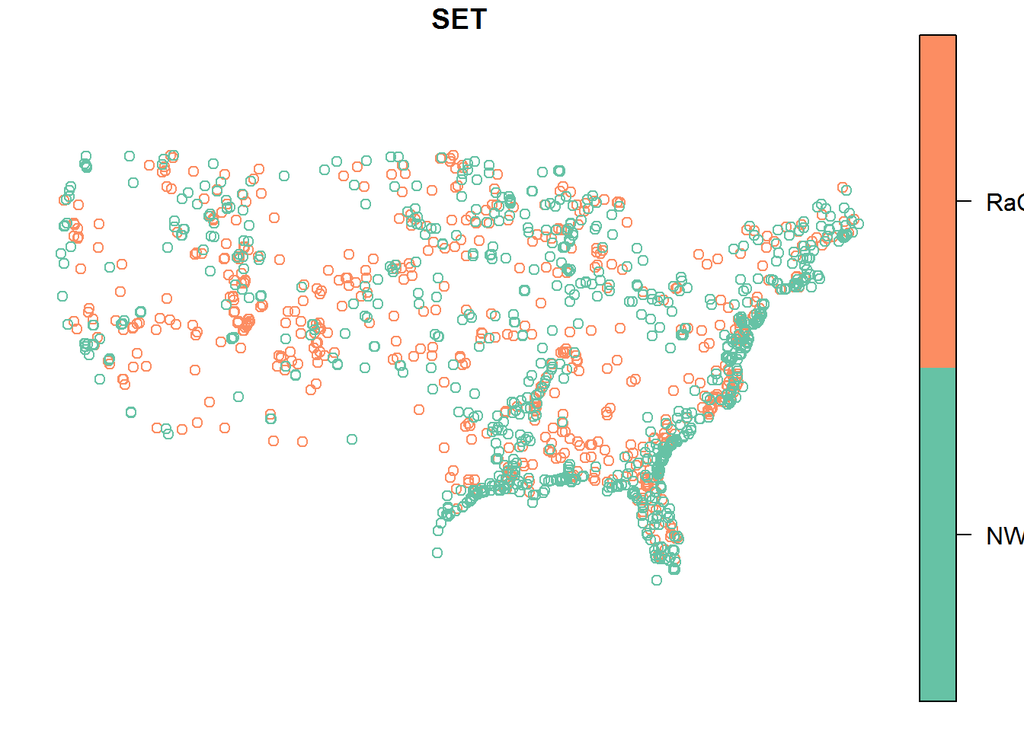

```r
# NOt working ggplot(Csf) + geom_sf(aes(color = SET))


plot(Csf["SET"])
```

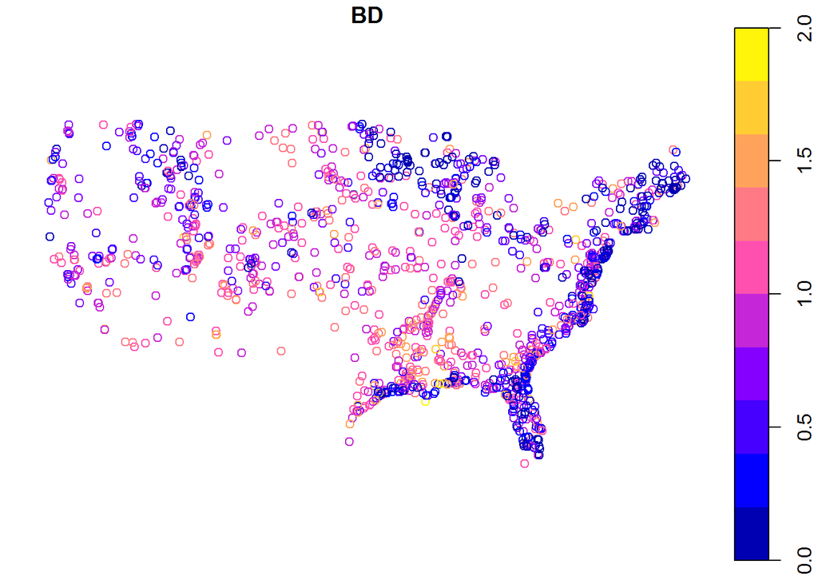

```r
plot(Csf["BD"])
```